# Red and White Wine Analysis

# Red vs White wine quality exploration

## About the dataset

The datasets analysed about red and white wine were created by Paulo Cortez, Antonio Cerdeira, Fernando Almeida, Telmo Matos and Jose Reis, the wines studied are the Portuguese “Vinho Verde” in its red and white variant, downloaded from [here](https://docs.google.com/document/d/1qEcwltBMlRYZT-l699-71TzInWfk4W9q5rTCSvDVMpc/pub). The following variables were taken into consideration:

1. Fixed acidity (tartaric acid - g / dm^3) – Most acids involved with wine or fixed or nonvolatile (do not evaporate readily).
2. Volatile acidity (acetic acid - g / dm^3) – The amount of acetic acid in wine, which at too high of levels can lead to an unpleasant, vinegar taste.
3. Citric acid (g / dm^3) – Found in small quantities, citric acid can add ‘freshness’ and flavor to wines.
4. Residual sugar (g / dm^3) – The amount of sugar remaining after fermentation stops, it’s rare to find wines with less than 1 gram/liter and wines with greater than 45 grams/liter are considered sweet.
5. Chlorides (sodium chloride - g / dm^3) – The amount of salt in the wine.
6. Free sulfur dioxide (mg / dm^3) – Free sulfur dioxide: the free form of SO2 exists in equilibrium between molecular SO2 (as a dissolved gas) and bisulfite ion; it prevents microbial growth and the oxidation of wine.
7. Total sulfur dioxide (mg / dm^3) – Amount of free and bound forms of S02; in low concentrations, SO2 is mostly undetectable in wine, but at free SO2 concentrations over 50 ppm, SO2 becomes evident in the nose and taste of wine.
8. Density (g / cm^3) – The density of water is close to that of water depending on the percent alcohol and sugar content.
9. pH – Describes how acidic or basic a wine is on a scale from 0 (very acidic) to 14 (very basic); most wines are between 3-4 on the pH scale.
10. Sulphates (potassium sulphate - g / dm3) – A wine additive which can contribute to sulfur dioxide gas (S02) levels, wich acts as an antimicrobial and antioxidant.
11. Alcohol (% by volume) – The percent alcohol content of the wine.
12. Quality (score between 0 and 10).

## Preparation of dataset

We start by loading the necessary libraries

```r
library(ggplot2)
library(dplyr)
library(GGally)
library(psych)
```

Loading the data and doing some data wrangling

```
## [1] 1599   12
```

```
## [1] 4898   12
```

```r
summary(rw)
```

```
##  fixed.acidity   volatile.acidity  citric.acid    residual.sugar
##  Min.   : 4.60   Min.   :0.1200   Min.   :0.000   Min.   : 0.900
##  1st Qu.: 7.10   1st Qu.:0.3900   1st Qu.:0.090   1st Qu.: 1.900
##  Median : 7.90   Median :0.5200   Median :0.260   Median : 2.200
##  Mean   : 8.32   Mean   :0.5278   Mean   :0.271   Mean   : 2.539
##  3rd Qu.: 9.20   3rd Qu.:0.6400   3rd Qu.:0.420   3rd Qu.: 2.600
##  Max.   :15.90   Max.   :1.5800   Max.   :1.000   Max.   :15.500
##    chlorides       free.sulfur.dioxide total.sulfur.dioxide    density
##  Min.   :0.01200   Min.   : 1.00       Min.   :  6.00       Min.   :0.9901
##  1st Qu.:0.07000   1st Qu.: 7.00       1st Qu.: 22.00       1st Qu.:0.9956
##  Median :0.07900   Median :14.00       Median : 38.00       Median :0.9968
##  Mean   :0.08747   Mean   :15.87       Mean   : 46.47       Mean   :0.9967
##  3rd Qu.:0.09000   3rd Qu.:21.00       3rd Qu.: 62.00       3rd Qu.:0.9978
##  Max.   :0.61100   Max.   :72.00       Max.   :289.00       Max.   :1.0037
##        pH          sulphates         alcohol         quality
##  Min.   :2.740   Min.   :0.3300   Min.   : 8.40   Min.   :3.000
##  1st Qu.:3.210   1st Qu.:0.5500   1st Qu.: 9.50   1st Qu.:5.000
##  Median :3.310   Median :0.6200   Median :10.20   Median :6.000
##  Mean   :3.311   Mean   :0.6581   Mean   :10.42   Mean   :5.636
##  3rd Qu.:3.400   3rd Qu.:0.7300   3rd Qu.:11.10   3rd Qu.:6.000
##  Max.   :4.010   Max.   :2.0000   Max.   :14.90   Max.   :8.000
```

## Single variable exploration

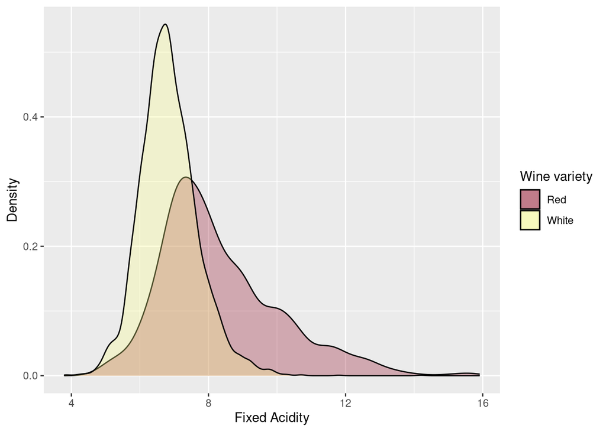

```
##    Min. 1st Qu.  Median    Mean 3rd Qu.    Max.
##    4.60    7.10    7.90    8.32    9.20   15.90
```

```
##    Min. 1st Qu.  Median    Mean 3rd Qu.    Max.
##   3.800   6.300   6.800   6.855   7.300  14.200
```

The range of values for fixed acidity is wide, most wines have its acidity from 7 to 9 g/dm^3 of tartaric acid.

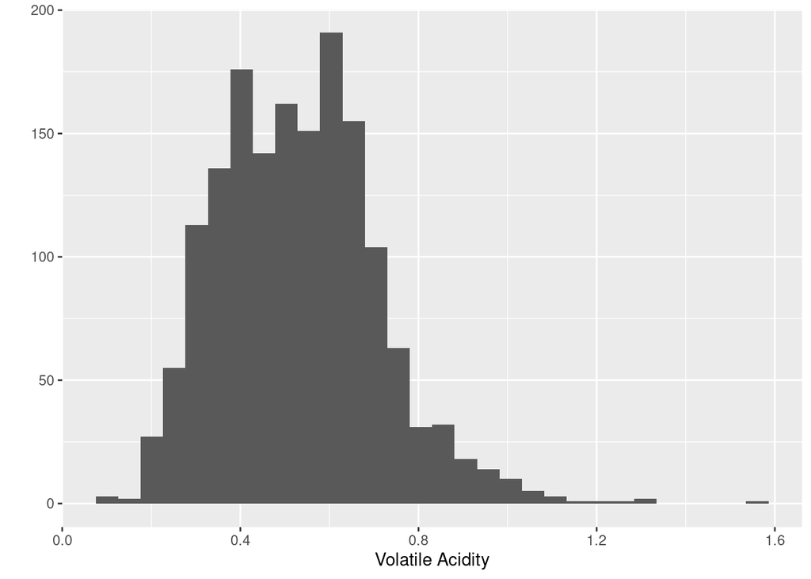

```
##    Min. 1st Qu.  Median    Mean 3rd Qu.    Max.
##  0.1200  0.3900  0.5200  0.5278  0.6400  1.5800
```

Volatile acidity also follows a normal distribution and its range of values is small, containing most of them between 0.4 and 0.65.

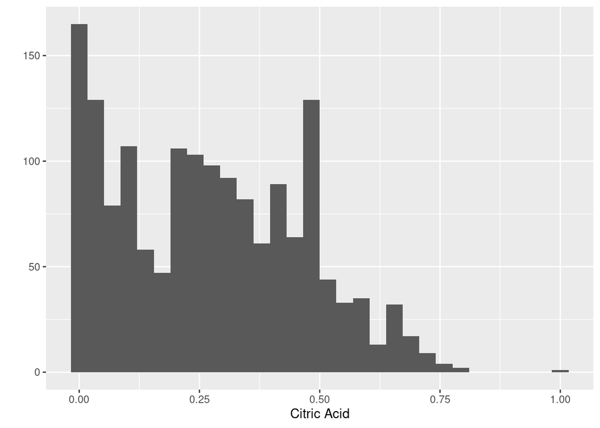

```
##    Min. 1st Qu.  Median    Mean 3rd Qu.    Max.
##   0.000   0.090   0.260   0.271   0.420   1.000
```

The data for citric acid concentrations does not appear normal, therefore a square root transformation is applied. Note that such transformation is possible due to the fact that there are no negative concentrations.

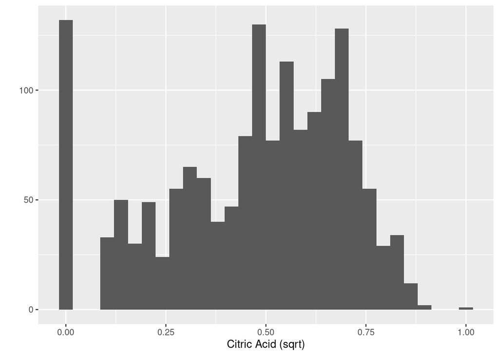

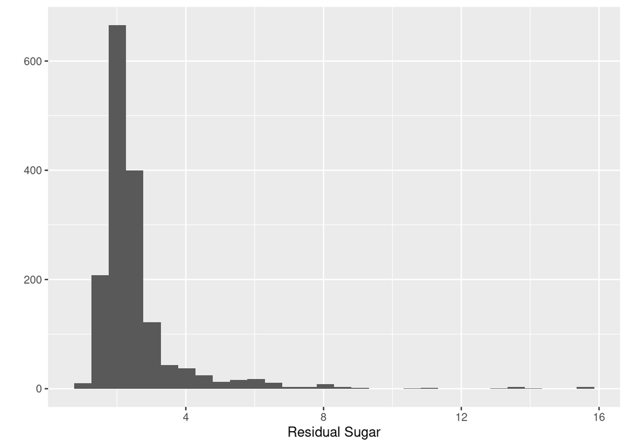

```
##    Min. 1st Qu.  Median    Mean 3rd Qu.    Max.
##   0.900   1.900   2.200   2.539   2.600  15.500
```

Residual sugar has a very wide range of values and presents decreasing exponential behavior, therefore a log10 transformation is applied.

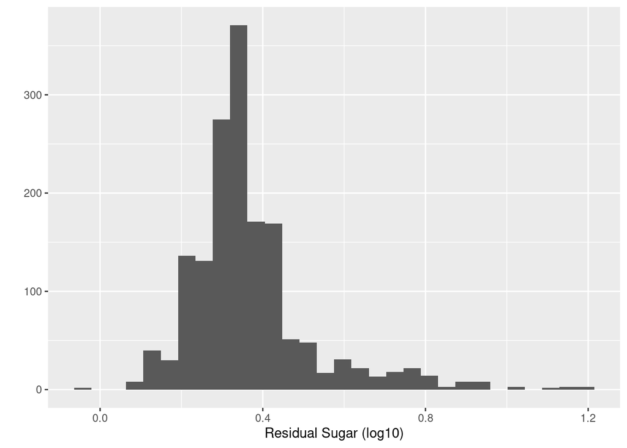

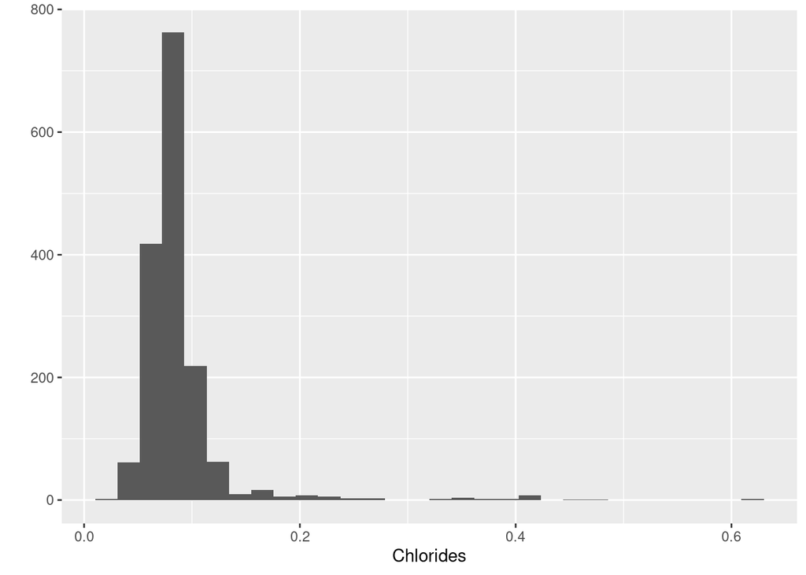

```
##    Min. 1st Qu.  Median    Mean 3rd Qu.    Max.
## 0.01200 0.07000 0.07900 0.08747 0.09000 0.61100
```

As with residual sugar all numbers are positive and chlorides show a decaying exponential pattern, the range of values is very small.

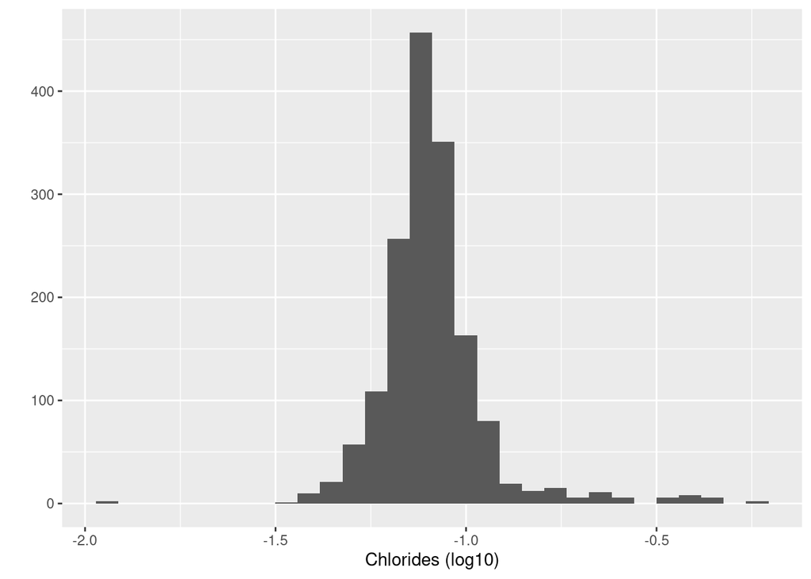

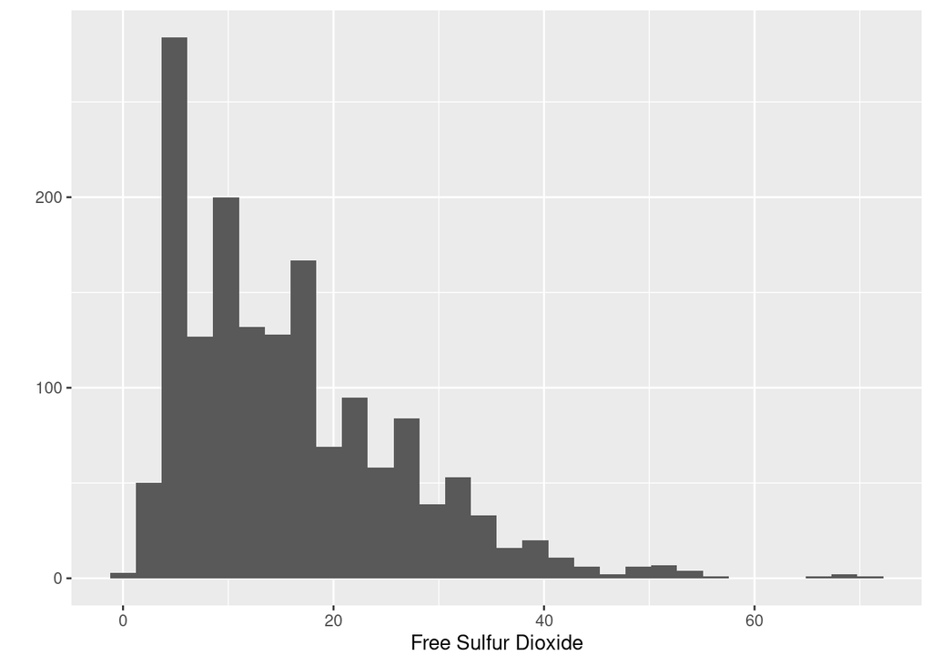

```
##    Min. 1st Qu.  Median    Mean 3rd Qu.    Max.
##    1.00    7.00   14.00   15.87   21.00   72.00
```

The range of values for free sulfur dioxide is very big, with a lenght of 71, however, the majority of values are in the range 7 to 21, this is due to the high density towards the cero, like a chi squared distribution. Therefore a sqrt transformation is applied.

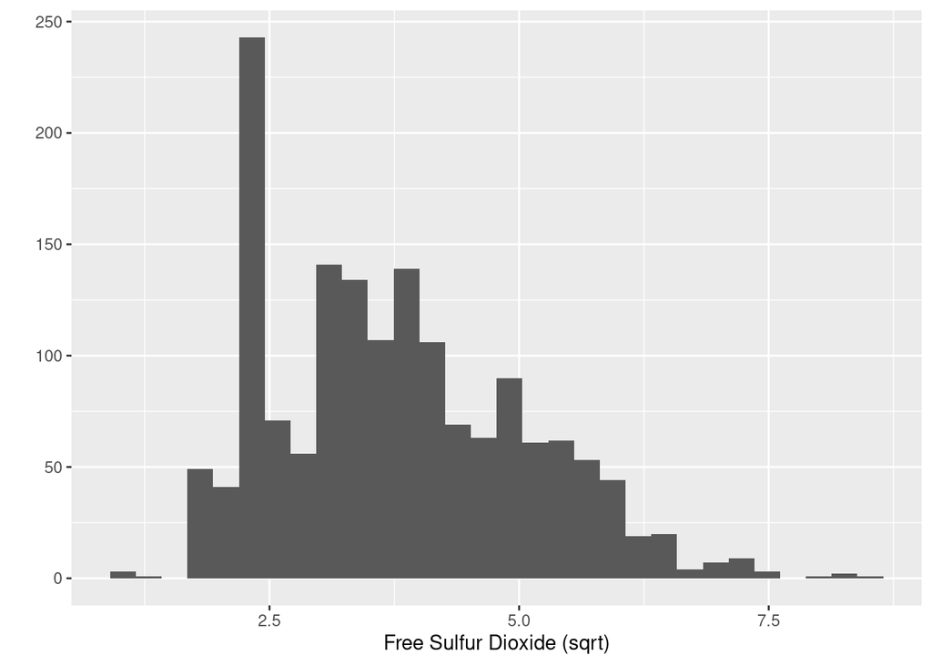

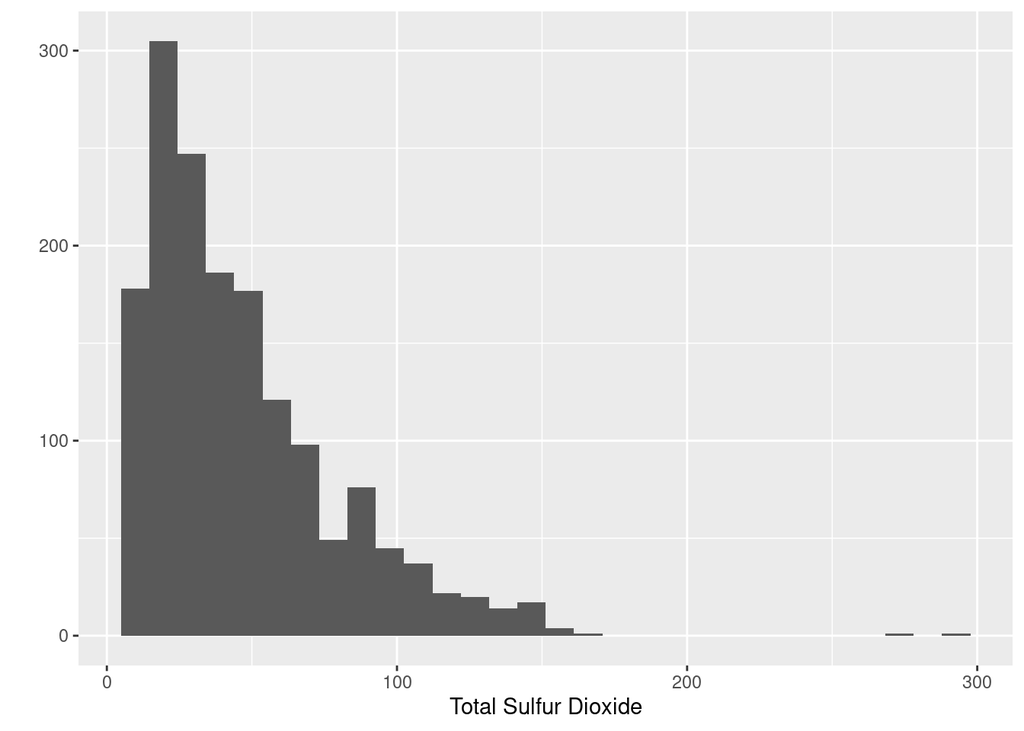

```
##    Min. 1st Qu.  Median    Mean 3rd Qu.    Max.
##    6.00   22.00   38.00   46.47   62.00  289.00
```

As expected, total sulfur dioxide has a behavior similar to the free distribution measure, with a higher maximum value. A sqrt transformation is applied.

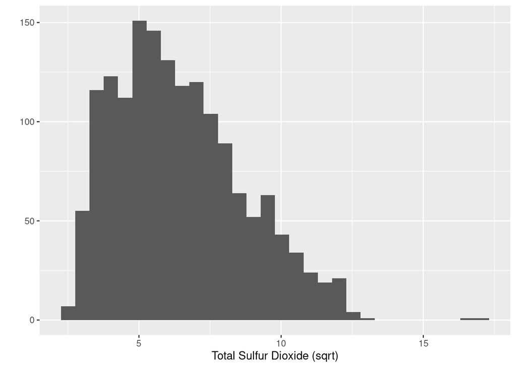

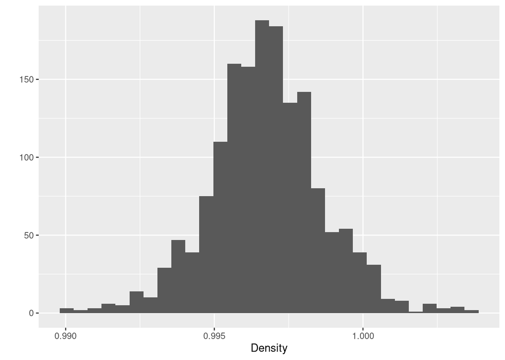

```
##    Min. 1st Qu.  Median    Mean 3rd Qu.    Max.
##  0.9901  0.9956  0.9968  0.9967  0.9978  1.0037
```

The density follows an almost perfect normal distribution with its values ranging from 0.99 to 1.0037.

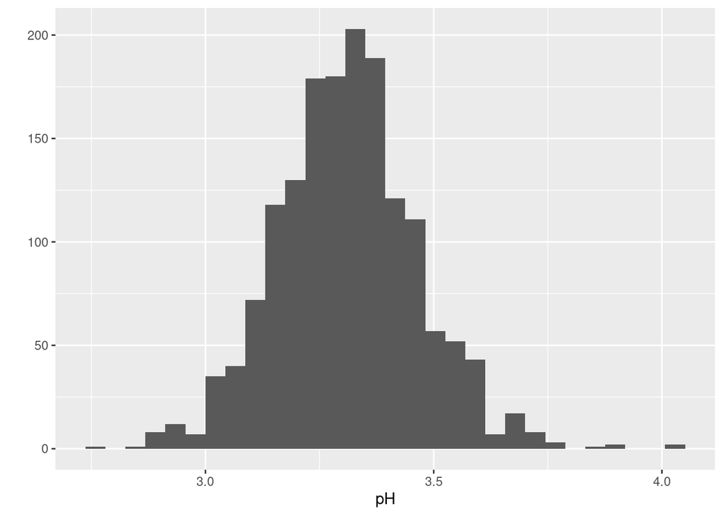

```
##    Min. 1st Qu.  Median    Mean 3rd Qu.    Max.
##   2.740   3.210   3.310   3.311   3.400   4.010
```

No transformation will be applied to the variable pH. Most values are in the range 3.2, 3.4 which is what was described in the original paper.

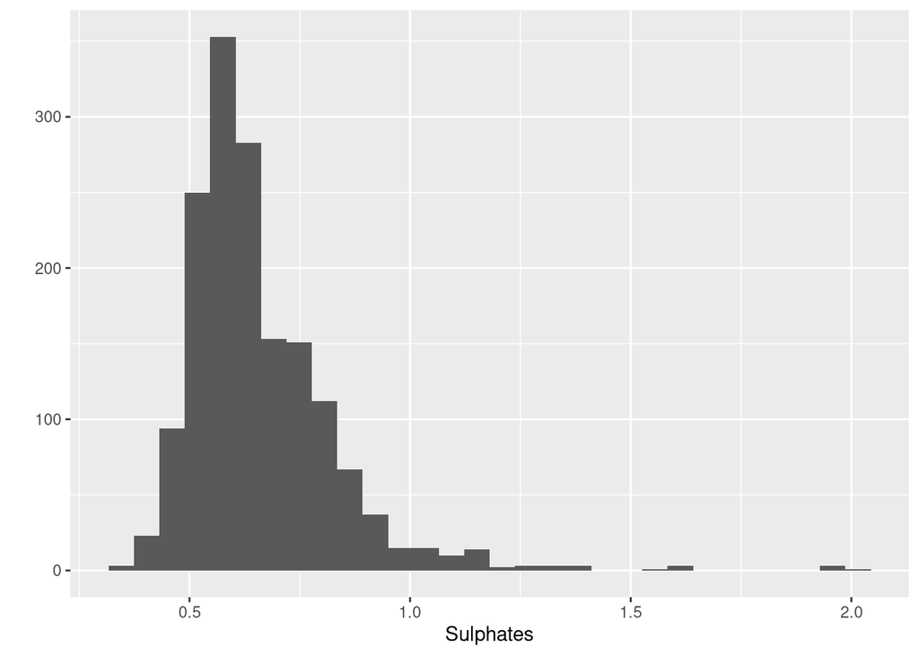

```
##    Min. 1st Qu.  Median    Mean 3rd Qu.    Max.
##  0.3300  0.5500  0.6200  0.6581  0.7300  2.0000
```

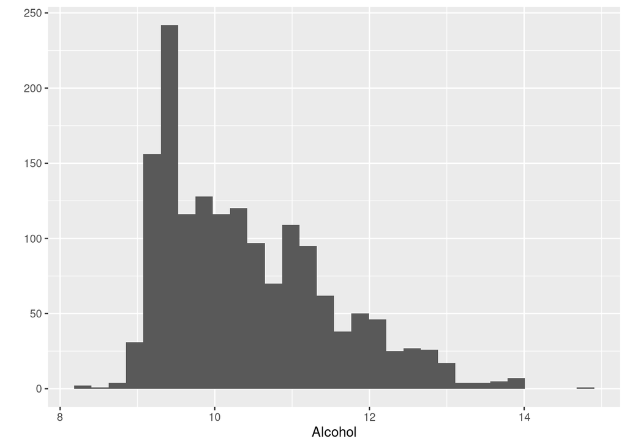

```
##    Min. 1st Qu.  Median    Mean 3rd Qu.    Max.
##    8.40    9.50   10.20   10.42   11.10   14.90
```

The alcohol variable does not look like a normal variable, but also not exponential. No transformation will be applied.

### What is the main feature of interest in the dataset?

The main features in the dataset are alcohol, residual sugar and quality. We would like to determine which features are best to predict the quality of a red wine. I suspect alcohol and residual sugar will be the most influential ones.

## Bivariate exploration

Now we study the correlation between the variables. To see if there is some pattern formed we will first look at a scatterplot matrix

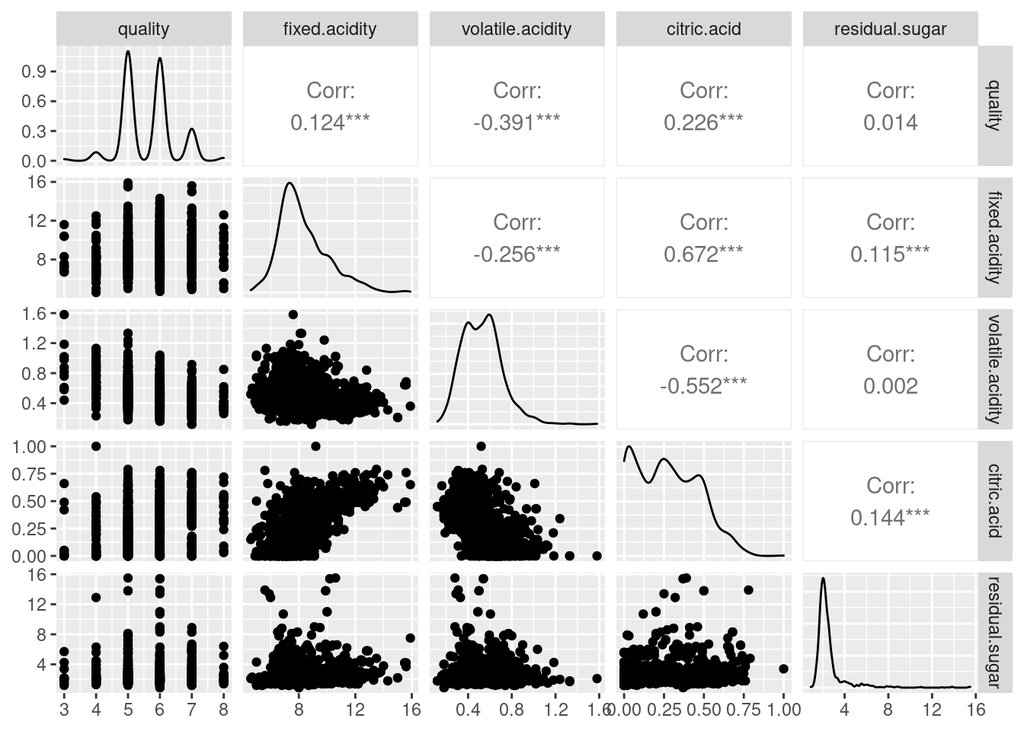

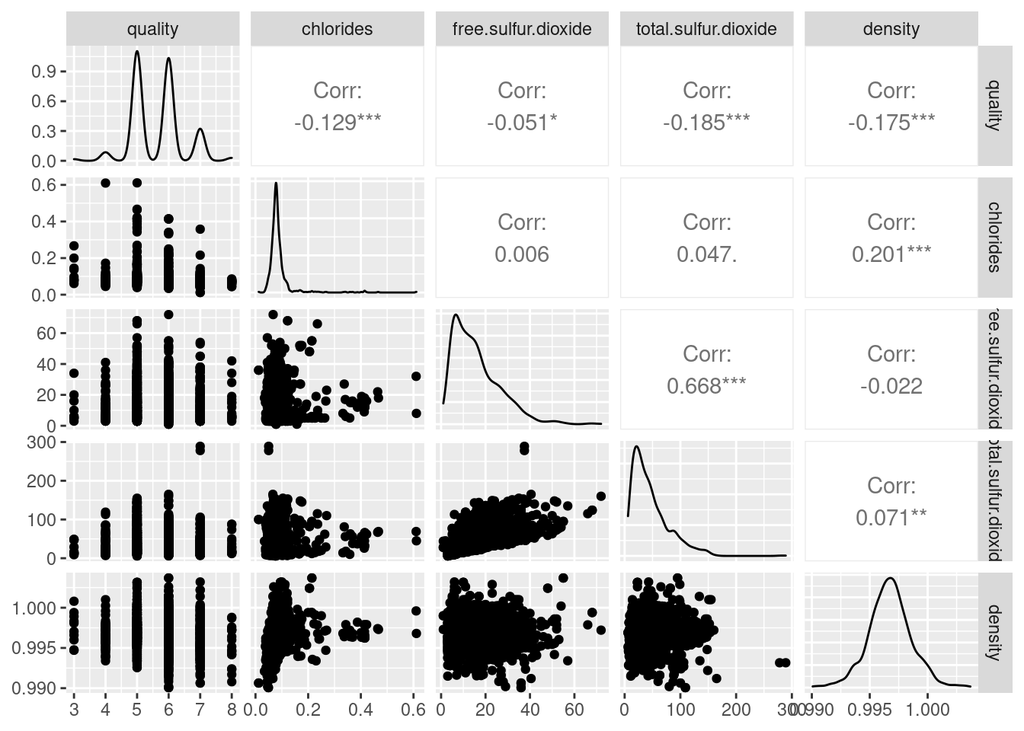

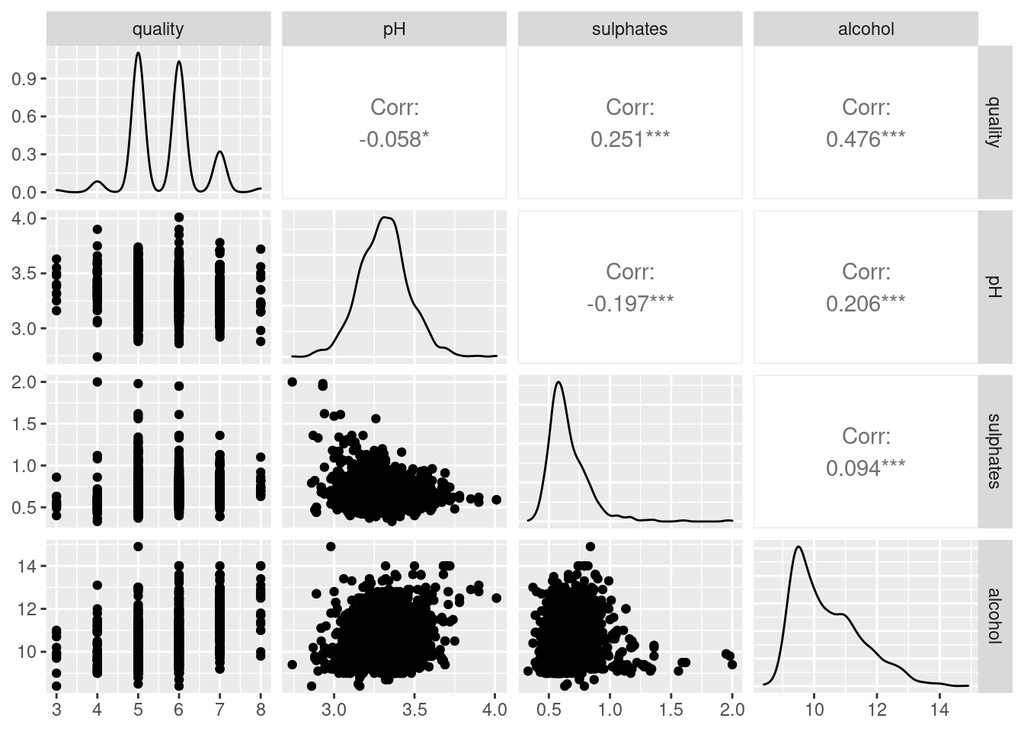

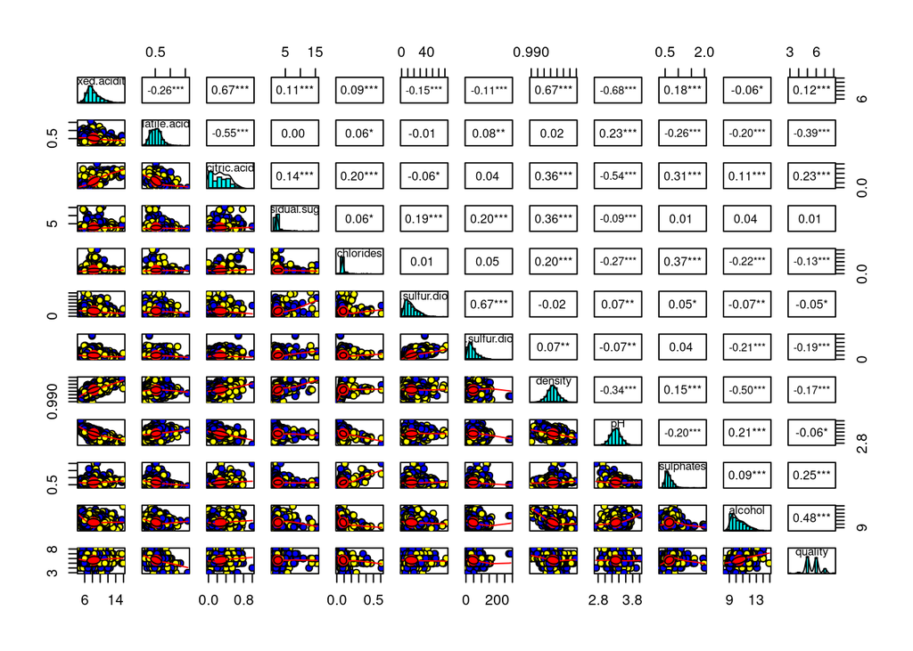

### Analysing alcohol

How much does alcohol percentage affect in quality? To study this we shall see the quality of those wines with alcohol within the middle 50% range and the quality for the outer 50% ranges.

**Middle 50% range:**

```
##    Min. 1st Qu.  Median    Mean 3rd Qu.    Max.
##   3.000   5.000   5.000   5.515   6.000   8.000
```

```
##    Min. 1st Qu.  Median    Mean 3rd Qu.    Max.
##    3.00    5.00    6.00    5.79    6.00    8.00
```

Apparently alcohol does not affect the quality much, however this might be due to the small range of alcohol percentages in our sample.

```
##    Min. 1st Qu.  Median    Mean 3rd Qu.    Max.
##    8.40    9.50   10.20   10.42   11.10   14.90
```

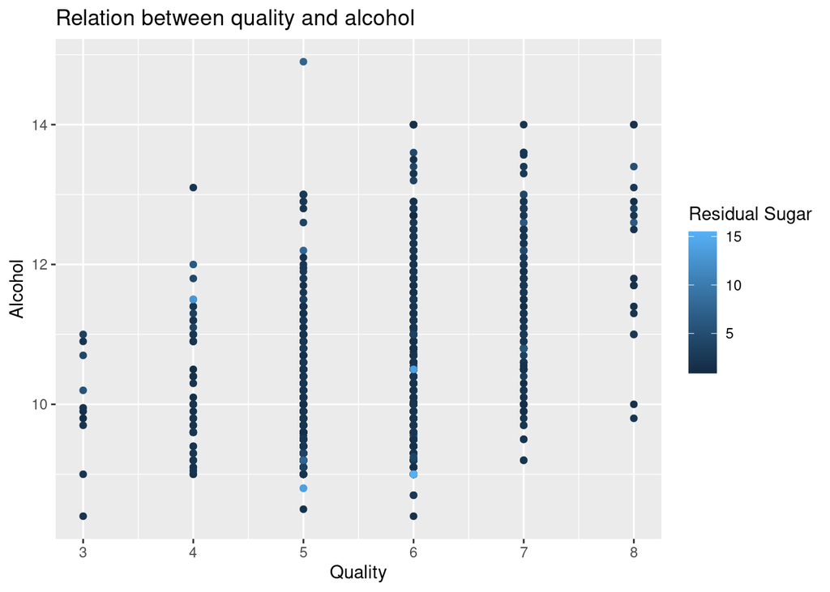

There seems to be a linear relation between the amount of alcohol and the quality of a red wine. **The residual sugar however does not seem to have enough variance to be worth studying**.